# report

Author

Rajan Topiwala & Ben Hopkins

Published

2/6/26

# Premium Growth Model Annual Report: 2026

##### Last Updated: Friday Feb 06, 2026

##### Author: Rajan Topiwala & Ben Hopkins

## Summary

The Premium Growth Model (PGM) is the Congressional Budget Office’s (CBO) primary tool for projecting health expenditures per privately insured person, which form the basis for forecasts of employer-sponsored and non-group health insurance premiums, employer contributions to HRAs and HSAs, and related plan characteristics. The PGM combines annual survey estimates of premium growth with CBO’s macroeconomic projections to produce both a near-term and long-term outlook for private health expenditures per capita.

For the Winter 2026 baseline, CBO projects premium growth of 7.1% in 2026, up from 5.5% in the Spring 2025 baseline. Growth is expected to remain elevated in the near term due to increased spending on costly specialty pharmaceuticals (especially oncology drugs and GLP-1s), continued behavioral health utilization, hospital price growth, and higher-than-normal inflation. Over the longer term, CBO expects these effects to normalize with premium growth, gradually converging to levels consistent with CBO’s longer-run projections for prices and income. The changes from the prior baseline primarily stem from three factors:

1. New premium growth survey data, showing steady premium growth of about 5% from 2023 to 2025, which modestly lowered projections in the early years but were offset by the macroeconomic and near-term adjustment updates;
2. Upward revisions to CBO’s macroeconomic forecast, reflecting higher medical price growth (PCEMED) due to tariffs and stronger personal disposable income (PDI) driven by strong economic performance and permanent tax cuts beginning in 2026;
3. Higher near-term growth adjustments of +2.0, +1.5, and +1.5 percentage points for 2024–2026, informed by Federal Employees Health Benefits (FEHB) data and expert input suggesting elevated premium growth in 2026 and 2027.

## Introduction

The Congressional Budget Office projects health expenditures per privately insured person through the 10-year baseline period using the PGM. The PGM generates factors used in CBO’s health insurance simulation model, HISIM2, to project increases in health spending, employment-based insurance (EBI) premiums, and employer contributions to health reimbursement accounts (HRAs) and health savings accounts (HSAs). The factors are also used to project growth in plan characteristics such as maximum out-of-pocket spending for EBI plans and for nongroup plans, and deductibles for nongroup plans. Additionally, the output of the PGM is used in HISIM2 to project growth in premiums for nongroup plans. The PGM’s output is also used by the Joint Committee on Taxation (JCT) and by other divisions across CBO.

The PGM is updated each year, and those updates are incorporated into CBO’s spring or winter baselines. The most recent PGM projections are for the winter 2026 baseline, and comparisons will be made relative to the spring 2025 baseline. One way to compare the two sets of projections is to focus on the projected expenditures for health care services per capita by insurers in the last year they share in common (2035). Looking at the figure below, the 2026 baseline updates to the PGM have increased projected expenditures per capita in 2035 by about $336 (2.5%).

For the Winter 2026 baseline, CBO projects slightly higher per capita health expenditures than it did in the Spring 2025 baseline. This year’s projection incorporates newly available survey data, updated CBO macroeconomic projections, and consults with experts and actuaries, who suggested that high growth rates are likely to persist through at least 2026 and 2027 before leveling out. In the near-term, these experts said that this increase is largely driven by the adoption of costly pharmaceuticals, most notably GLP-1s and oncology medications, but it also reflects broader growth in spending on hospital costs and behavioral/mental health care. Critically, this baseline forecast has been produced before the 2024 actual premium data became available: the last historical actual used in the projection is from 2023, which is the same as last baseline.

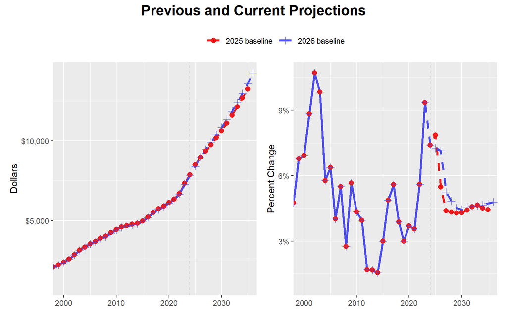

## Overview of the Premium Growth Model (PGM)

The PGM is a set of two time-series regression models used to project growth in health expenditures per privately insured person. These projections serve as the basis for premiums in CBO’s modeling. Health expenditures, in this context, include amounts paid by the health insurer and administrative expenses incurred by the insurer. It excludes cost sharing paid by the patient at the point of service and out-of-pocket spending on noncovered services. Private health insurance includes EBI plans and nongroup plans and excludes medigap, Medicare Advantage, and Medicaid managed care plans.

The first of the two models, the current-year model, projects expenditures in years for which estimates of growth in premiums or per-capita health expenditures are available from surveys or other sources but not from the National Health Expenditure Accounts, generally one year. The second, the primary model, projects expenditures for the remainder of the forecast window using an autoregressive term and CBO’s macroeconomic forecast. The 2026 PGM uses growth in real income to project real health expenditures per privately insured person. The projected real health expenditures are then combined with projected prices (PCEMED) to produce nominal projected expenditures per capita.

### Data

The key source for historical estimates of expenditures per capita is the National Health Expenditure Accounts (NHEA).[^1] CBO modifies those data in two ways. First, estimated medigap plan expenditures and medigap enrollment are removed. Second, expenditures are adjusted to remove the effects of onetime events that significantly affected expenditure growth but should not be reflected in the long-term equilibrium–namely the establishment of health insurance marketplaces under the Affordable Care Act[^2] and the COVID-19 pandemic.

The ACA marketplaces significantly altered the individual insurance market by expanding coverage and introducing new subsidies, but their impact on expenditure growth rates varied over time. In the initial years, there was a surge in enrollment, particularly among previously uninsured individuals with preexisting health care needs, leading to a temporary spike in expenditures. Over time, as the market stabilized and risk pools adjusted, expenditure growth rates may have normalized, which is why CBO views the establishment of those marketplaces more as a onetime shock than a permanent change in trend.

CBO creates two versions of the historical and projected expenditures. One version includes an adjustment to exclude any growth due to changes in the age and sex composition of the privately insured population, and the other version does not include that adjustment. HISIM2 uses premium growth projections that exclude the effects of demographic changes because the microsimulation model implicitly accounts for those changes while projecting insurance coverage.[^3] To create the age- and sex-adjusted version, CBO uses the Current Population Survey (CPS) to estimate, for each historical year, the share of the privately insured population with each combination of single year of age and sex. CBO then applies the spending patterns estimated by Dale H. Yamamoto (2013) to estimate the change in expenditures attributable to demographic changes and creates an annual index used to scale estimates of health expenditures per privately insured person.[^4]

Other inputs to the model include [CBO’s historical data and economic projections](https://www.cbo.gov/data/budget-economic-data#11). Those variables include the total U.S. population (including members of the armed forces overseas and the institutionalized population), personal disposable income (PDI), the personal consumption expenditures price index for consumer goods (PCE). For the PGM, CBO also uses historical and projected values of the personal consumption expenditures price index for medical spending (PCEMED).

CBO adjusts both the expenditure and income variables during the pandemic period because the pandemic resulted in higher PDI and a temporary decrease in utilization of health care services. That decrease in utilization resulted in low expenditure growth in 2020 and high expenditure growth in 2021 as utilization rebounded. Without adjustment, those outliers may result in less accurate coefficient estimates and affect the projections through the autoregressive terms in the model. CBO adjusts income because stimulus payments in 2021 and 2022 provided a temporary boost to income that was slowly spent down over subsequent years. Less significantly, many people realized large capital gains in 2021 because of excess liquidity from the 2020 stimulus checks and other pandemic-related fiscal measures. CBO smoothed those fluctuations in income under the assumption that health spending responds more to permanent changes in income than temporary ones over the medium run.

### Methods

The PGM consists of two models: the current-year model and the primary model. The current year model is used to project real health expenditures per capita in the first year of the forecast window. The primary model is used to project health expenditures for the remaining years of the window. As the primary model is an autoregressive model, the projection of the current-year model is an input to the projection of the primary model.

The current-year regression model calculates preliminary estimates of growth in private health expenditures per capita from 2023 to 2025. That model is estimated using historical data through 2023 on growth in premiums for EBI plans and then used to project growth in expenditures in 2024 and 2025. This model is necessary because 2023 is the last year of historical data used from the NHEA, but other sources provide useful information on growth in private premiums from 2023 to 2024 and from 2024 to 2025. The sources for this regression model are the Bureau of Labor Statistics’ (BLS’s) producer price index (PPI) for comprehensive medical insurance plans, and KFF’s Employer Health Benefits Survey (EHBS).[^5]

To further refine its estimates, CBO conducted a series of stakeholder interviews and reviewed data from other sources including the Federal Employees Health Benefits program. Stakeholders were selected to represent the views of the insurance industry, actuaries, and employers in their role as purchasers of health benefits. When there are sustained deviations between NHEA and survey data used for produce the current-year projections or those sources suggest that there are factors driving expenditure growth that are not reflected in CBO’s macroeconomic projection, CBO applies adjustment factors to the projections from the premium growth model.

The following table summarizes the PGM methodology applied to the Winter 2026 baseline:

| **Factor** | Winter 2026 |
| --- | --- |
| Near-term projection | Preliminary estimate of growth from 2023 to 2024 and 2024 and 2025 based on current-year model |
| Near-term adjustments | Growth from 2023 to 2024, 2024 to 2025, and 2025 to 2026 increased by 2, 1.5, and 1.5 percentage points, respectively, based on FEHB data, expert interviews, and literature |
| PGM: Estimation period | 1999-2023 (*N* = 25) |
| PGM: Dependent variable | Log difference in health expenditures per capita deflated by PCEMED |
| PGM: Lagged dependent variable terms | One |
| PGM: Income variable | Six-year log difference in PDI per capita deflated by PCE |
| PGM: Estimator | Ordinary least squares |

## Changes to the Projection

To facilitate the comparison of the spring 2025 and winter 2026 projections, changes in the estimates are decomposed into a series of steps:

1. **Updating the Historical Data:** Changes resulting from updating the data on expenditures per capita, the demographic composition of the privately insured population, and survey data on premium growth. The macroeconomic forecast and the specification and coefficients of the primary model are held fixed.
2. **Updating the Macroeconomic Forecast:** Changes resulting from updating the macroeconomic forecast. The specification and coefficients of the primary model are held fixed.
3. **Updating the Coefficients of the Previous Model Specification:** Changes resulting from updating the coefficient estimates using the model specification for the primary model from the previous baseline. The specification of the primary model is held fixed.
4. **Updating the Model Specification:** Changes resulting from updating the specification of the primary model.
5. **Adjusting the Near-Term Projections:** Adjustments are made to the current-year estimate(s) and the estimate for the first year of the projection. These adjustments reflect stakeholder input and data not otherwise formally incorporated in the projection.

### Step 1: Updating the Historical Data

As shown in the chart below, CBO’s projection of expenditures per capita in 2035 has slightly decreased by -$104 (-0.8%) since last year as a result of incorporating an additional year of survey data on health insurance premiums. As this forecast was produced before new NHEA data became available, the data are virtually unchanged through 2024. The KFF and BLS survey estimates of premium growth used to estimate the current year model ranged between 4.2% and 6.7% for 2025. Incorporating these estimates yielded a small downward change in the forecast from 2025 on.

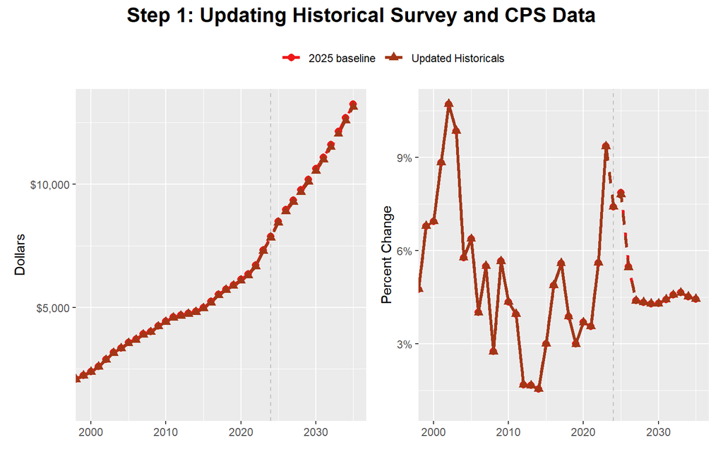

### Step 2: Updating the Macroeconomic Forecast

The updates to CBO’s MAD forecast pushed up projections of health expenditure growth in 2026 and over the window. Relative to macroeconomic projection used in last year’s baseline, PCMED is higher in the near-term due primarily to the effect of tariffs. PDI also varies considerably compared to last baseline’s forecast: PDI is higher in 2025 than previously projected due to higher historical actuals and stronger economic growth seen in the incoming macroeconomics data for the first half of 2025. PDI experiences another one-time jump to higher levels in 2026 due to the implementation of permanent tax cuts taking effect, but PDI growth subsequently returns to normal levels thereafter.

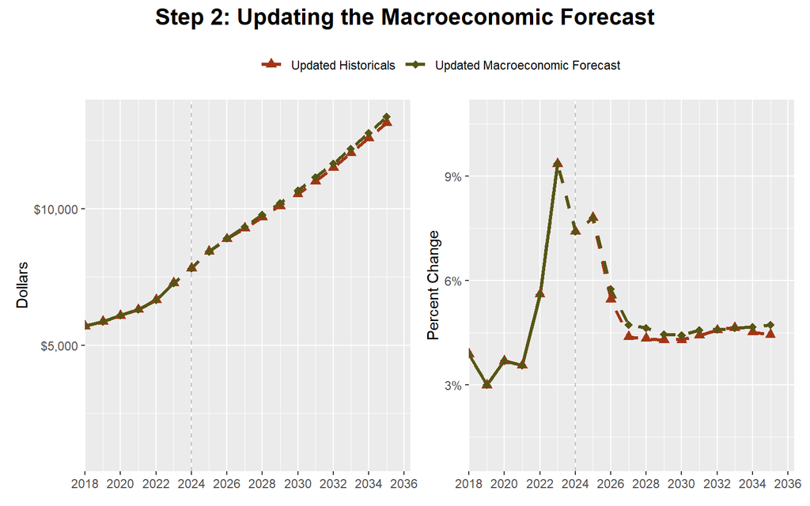

### Step 3: Updating the Coefficients of the Previous Model Specification

In Step 3, CBO reestimates the spring 2025 specification using the updated input data and projects expenditure growth using the updated coefficient estimates. As the Winter 2026 baseline was produced before the new NHEA data became available and the revisions to the historical macroeconomic data were relatively minor, the effects of updating the coefficients for the primary model are negligible for this baseline.

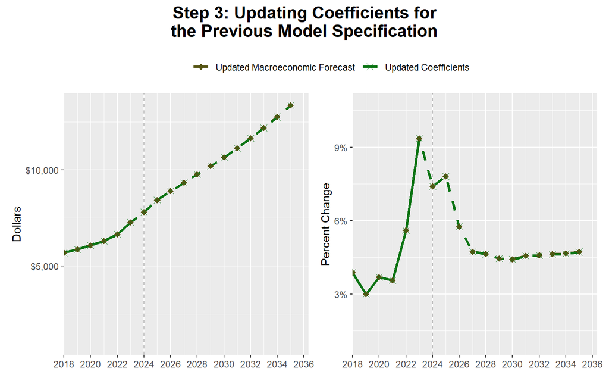

### Step 4: Updating the Model Specification

This step has no impact on the forecast because the model specifications have not changed since the spring 2025 baseline.

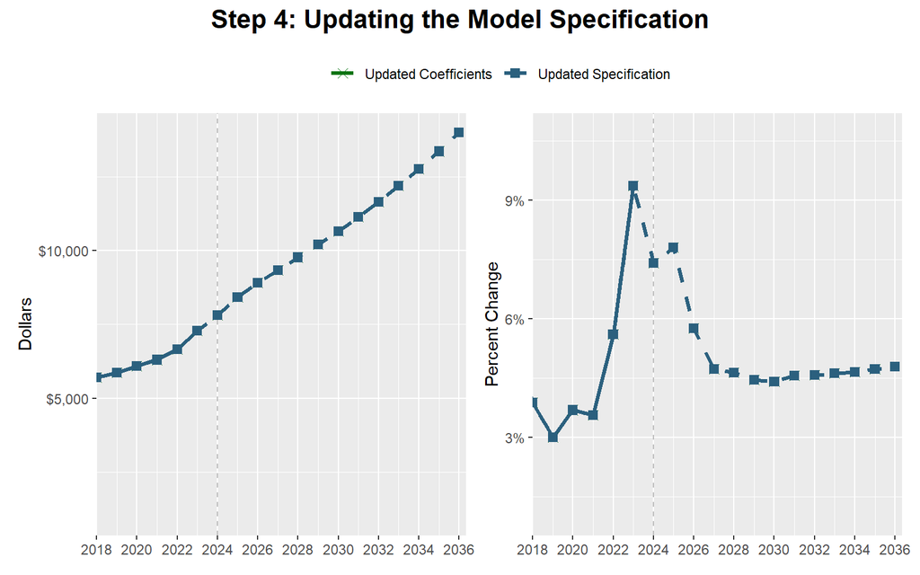

### Step 5: Adjusting the Near-Term Projections

The final projections incorporate approximately 2.0, 1.5, and 1.5 percentage point boosts to growth in 2024, 2025, and 2026.[^7] The projections incorporate adjustments when there are sustained deviations between NHEA and survey data and / or when factors that strongly affect expenditure growth are not reflected in CBO’s macroeconomic projections. FEHB data, articles, and calls with outside experts suggest that premium growth was high relative to historical levels in 2025 and will remain elevated in 2026 and 2027 due to higher-than-normal inflation, hospital price growth, specialty pharmaceutical utilization growth especially oncology and GLP-1s and continued behavioral health utilization. Meanwhile, survey data suggest growth was steady in 2025. As such, the adjustments were chosen to ensure that the projections were elevated but decreasing between 2025 and 2027.

The following table summarizes the near-term adjustments:

| **Baseline** | 2024 | 2025 | 2026 |
| --- | --- | --- | --- |
| Spring 2025 | +2 p.p. | +2 p.p. | +0 p.p. |
| Winter 2026 | +2 p.p. | +1.5 p.p. | +1.5 p.p. |

[figure not shown]

### Additional Projections: Health Care Expenditures Per Capita Without Demographic Adjustment

CBO also produces projections of health expenditures per capita that incorporate changes in the age and sex composition of the privately insured population. The agency generates those predictions by estimating the same current-year and primary models using data that have not been adjusted for demographics. The difference between the adjusted and unadjusted projections (in log differences) represents the implied change in health expenditures per capita due to demographic changes. As growth in the unadjusted projections exceeds growth in the adjusted projections, CBO is implicitly forecasting that demographic changes will contribute positively to growth in health expenditures per capita over the next 10 years. That expected trend is consistent with the continued aging of the U.S. population.

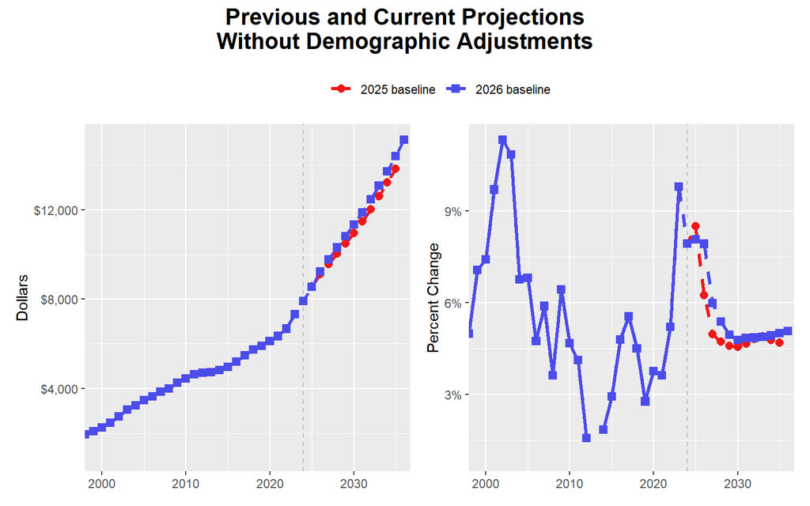

## Glossary

- **Health expenditures per capita**

The premium growth model uses data on private enrollment and expenditures from Table 21 of the National Health Expenditure Accounts to create private per capita premiums. National health expenditures equal health consumption expenditures plus the sum of medical-sector purchases of structures and equipment and expenditures for noncommercial medical research (investment).

Private Per Capita Premiums = Total Private Health Insurance Expenditures / Total Private Health Insurance Enrollment

Sources: [Centers for Medicare & Medicaid Services, “Historical”](https://www.cms.gov/data-research/statistics-trends-and-reports/national-health-expenditure-data/historical) (accessed January, 2025), and [Bureau of Economic Analysis, NIPA Handbook: Concepts and Methods of the U.S. National Income and Product Accounts, Chapter 5](https://www.bea.gov/resources/methodologies/nipa-handbook) (December 2024), .

- **Personal consumption expenditures price index for medical spending (PCEMED)**

The premium growth model uses PCEMED to measure medical prices and deflate nominal private health insurance expenditures per capita. Historical values of PCEMED are taken from the Bureau of Economic Analysis’s (BEA’s) National Income and Products Accounts (NIPAs), and projections are done by CBO.

PCEMED has three subcomponents:

- PCE: Therapeutic Appliances & Equipment Price Index , also known as PCDMED, which comprises 2 percent of PCEMED
- PCE: Pharmaceutical & Other Medical Products Price Index, also known as PCNMED, which comprises 17 percent of PCEMED
- PCE: Health Care Services, also known as PCSMED, which comprises 81 percent of PCMED

CBO’s projections of PCDMED and PCNMED are based on simple autoregressive moving average models. The agency’s projections of PCSMED, which makes up the bulk of the PCEMED index, involve an iterative process within CBO between MAD and the Budget Analysis Division.

Key steps for projecting PCSMED include:

1. Forecasting producer price indexes (PPIs) for inpatient care, outpatient care, and physician care
2. Using those PPIs to forecast PCE price indexes for hospital care and physician care
3. Aggregating the resulting PCE indexes along with the employment cost index (ECI) to forecast the overall PCE for medical services

Equation for PCSMED (as of spring 2024), where the Greek letter pi represents growth in a price index, beta represents an estimated coefficient, and epsilon is an error term:

$$\pi_t^{\text{PCSMED}} = \beta_1\pi_{t-1}^{\text{PCSMED}} + \beta_2\pi_t^{\text{PCE for hospital care}} + \beta_3\pi_t^{\text{PCE for physician care}} + \beta_4\text{ECI}_t + \epsilon_t$$

The following table describes some of the key differences between PCEMED and the Consumer Price Index: Medical care (CPI-M).

| Factor | PCEMED | CPI-M |
| --- | --- | --- |
| Scope | Includes direct payments made by consumers and third-party payments made on behalf of consumers | Only includes out-of-pocket expenditures made by consumers |
| Construction | Fisher price index | Laspeyres index |
| Data sourcing | Sector-specific PPIs and sector-specific CPIs | Consumer surveys |
| Usage as medical care deflator | Adjusting for purchasing power changes on personal consumption expenditures | Adjusting for purchasing power changes in out-of-pocket expenditures |

- **Personal consumption expenditures price index for consumer goods (PCE)**

The premium growth model uses PCE to deflate growth in personal disposable income. This series is taken and processed from the Bureau of Economic Analysis’s National Income and Products Accounts (NIPA) data. In the NIPAs, final consumption expenditures by households or nonprofit institutions serving households represent the portion of PCE for services provided to households without explicit charge, like the value of nonprofit college education exceeding tuition and fees. It equals their gross output, calculated as current operating expenses (excluding capital investments) minus sales to households and other sectors and the value of investment goods.

Source: Congressional Budget Office, [*Historical Data and Economic Projections*](https://www.cbo.gov/data/budget-economic-data#11) (accessed January, 2025).

- **Personal Disposable Income (PDI)**

The PGM uses real PDI, meaning nominal PDI divided by PCE, as an explanatory variable for real premium growth. PDI is the income that is left after people pay their taxes, and so is also known as after-tax income.

Source: Congressional Budget Office, [*Historical Data and Economic Projections*](https://www.cbo.gov/data/budget-economic-data#11) (accessed January, 2025); and Bureau of Economic Analysis, [*Income & Saving*](https://www.bea.gov/resources/learning-center/what-to-know-income-saving) (accessed January, 2025).

- **Yamamoto index**

Dale H. Yamamoto measured health care spending among a sample of enrollees in commercial health insurance, by single year of age and sex. Those spending measures are combined with enrollment data from the Current Population Survey and are used to estimate the role of demographic changes in the historical trends in private health expenditures per capita.

Source: Dale H. Yamamoto. [*Health Care Costs—From Birth to Death*](https://www.soa.org/resources/research-reports/2013/research-health-care-birth-death/) (2013).

## Footnotes

[^1]: For definitions of terms used in this report, please refer to the Glossary at the end of this report.
[^2]: The growth rate is increased by half a percentage point in 2013 and decreased by half a percentage point in 2014 to account for the effects of the Affordable Care Act.
[^3]: For the Joint Committee on Taxation, CBO produces a version of the projections that does not account for demographic changes. For that purpose, the series includes all other modifications discussed in this report and is projected using the same model specification.
[^4]: Dale H. Yamamoto. [*Health Care Costs—From Birth to Death*](https://www.soa.org/resources/research-reports/2013/research-health-care-birth-death/) (2013).
[^5]: See Bureau of Labor Statistics, [*PPI industry data for Direct health and medical insurance carriers-Comprehensive medical service plans, not seasonally adjusted*](https://data.bls.gov/timeseries/PCU524114524114101) (accessed January, 2025). For more information on the EHBS, see Gary Claxton, Matthew Rae, Aubrey Winger, and Emma Wager, [*Employer Health Benefits: 2025 Annual Survey*](https://files.kff.org/attachment/Employer-Health-Benefits-Survey-2025-Annual-Survey.pdf) (October 2025).
[^6]: For convenience, the model includes the PCEMED index as an explanatory variable with a fixed coefficient of one. That approach is equivalent to estimating the model and generating predictions in real terms then multiplying the predictions by PCEMED to convert them to nominal terms.
[^7]: The boosts are applied to projections of the log difference in real expenditure growth, as this is the dependent variable in the primary model. When transformed into percent growth in nominal expenditures, the boosts differ slightly.